# Operating Models Summary Report

North Atlantic Swordfish MSE

Adrian Hordyk adrian@bluematterscience.com

June 03, 2020

# 1 Operating Model Scenarios

## 1.1 Base Case Model

Table 1. Key parameter values for the base case analysis. The column names are: Natural mortality (M) - fixed parameter; standard error of recruitment deviations (sigmaR) - fixed parameter; Steepness (h) - estimated in the base case model; Coefficient of variation for the indices (CPUE CV) - varied between indices and years (range of values shown here); Effective sample size of length composition (Len. Comp. Eff. Samp. Size) - fixed; Q Increase assumed for indices (Q increase); Environmental covariate included for some indices (Env. Covariate).

| M | sigmaR | h | CPUE CV | Len. Comp. Eff. Samp. Size | Q increase | Env. Covariate |
| --- | --- | --- | --- | --- | --- | --- |
| 0.2 | 0.2 | 0.823509 | 0.16 - 0.38 | 20 | FALSE | TRUE |

## 1.2 Uncertainty Grid

Table 2. The uncertainty grid is a full factorial design with the following 7 factors, resulting in 288 OMs. M and h were fixed in the uncertainty grid. CPUE CV was fixed for all indices.

| M | sigmaR | h | CPUE CV | Len. Comp. Eff. Samp. Size | Q increase | Env. Covariate |
| --- | --- | --- | --- | --- | --- | --- |
| 0.1 | 0.2 | 0.60 | 0.3 | 2 | 1 | FALSE |
| 0.2 | 0.6 | 0.75 | 0.6 | 20 | 1.01 | TRUE |
| 0.3 |  | 0.90 |  |  |  |  |

# 2 Convergence

All 288 OMs in the uncertainty grid converged (invertible hessian).

# 3 Check for Parameters at Bounds

73 OMs had parameters that were close to the specified bounds (defined here as within 1% of the bounds). This only occurred for 3 parameters, all related to the size-selectivity parameters of the Japan Early and US fishing fleets.

Table 3. Table of parameters where the estimated values were within 1% of the specified minimum and maximum bounds. Filters at the top of each column can be used to subset the results. The table can be downloaded as a CSV file using the ‘CSV’ button.

| OM | Parameter | Value | Min | Max |
| --- | --- | --- | --- | --- |
| 3 | SizeSel_5P_1_JPN_ERLY_5 | 316.811 | 70 | 317 |
| 6 | SizeSel_5P_1_JPN_ERLY_5 | 316.793 | 70 | 317 |
| 9 | SizeSel_5P_1_JPN_ERLY_5 | 316.894 | 70 | 317 |
| 12 | SizeSel_5P_1_JPN_ERLY_5 | 316.867 | 70 | 317 |
| 14 | SizeSel_5P_1_JPN_ERLY_5 | 316.536 | 70 | 317 |
| 15 | SizeSel_5P_1_JPN_ERLY_5 | 316.914 | 70 | 317 |
| 17 | SizeSel_5P_1_JPN_ERLY_5 | 316.178 | 70 | 317 |
| 18 | SizeSel_5P_1_JPN_ERLY_5 | 316.887 | 70 | 317 |
| 27 | SizeSel_5P_1_JPN_ERLY_5 | 315.158 | 70 | 317 |
| 33 | SizeSel_5P_1_JPN_ERLY_5 | 316.441 | 70 | 317 |

[output cut: 66 more lines]

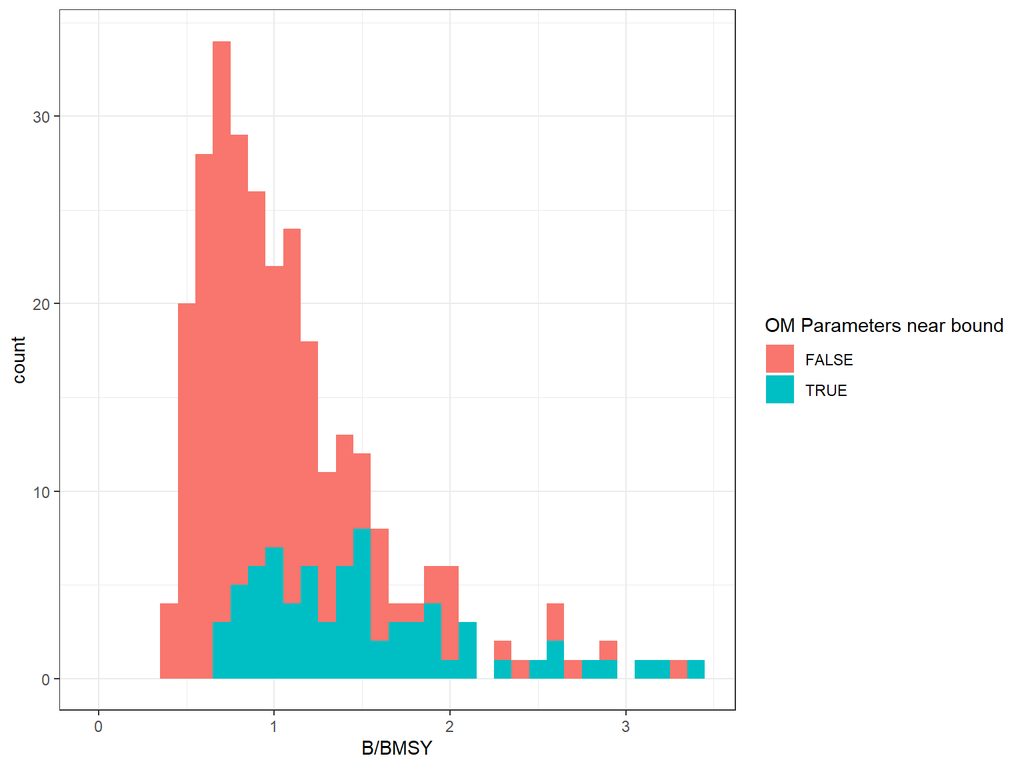

Figure 1. Histogram of the estimated stock status (B/BMSY) in 2017 with colours showing the OMs with some selectivity parameters close to the bounds.

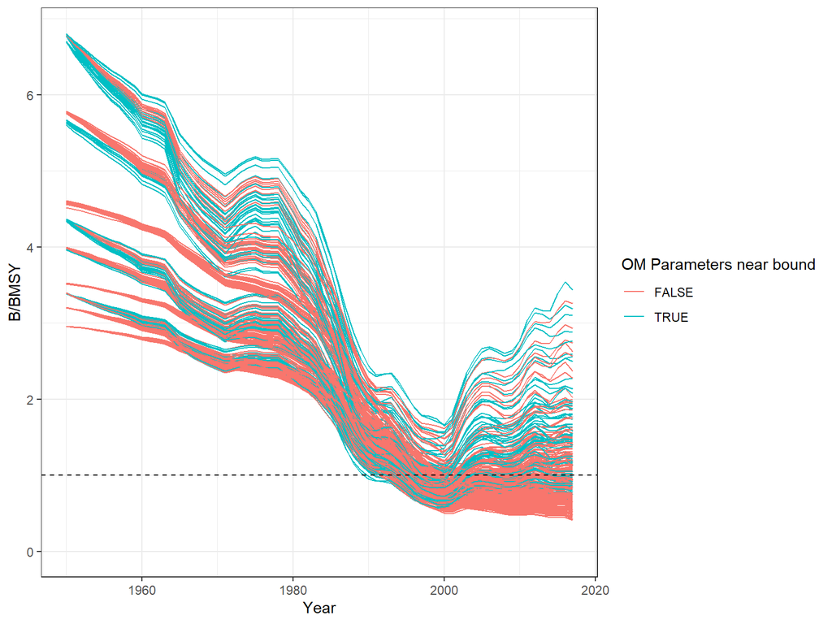

Figure 2. Time-series plot of B/BMSY with colours showing the OMs with some selectivity parameters close to the bounds. B/BMSY = 1 is shown as a dashed black line.

# 4 Parameter and Likelihood Table

Table 4. The parameters and the total and component negative log-likelihood values for the base case model and the 288 OMs from the uncertainty grid. Filters at the top of each column can be used to subset the results. The table can be downloaded as a CSV file using the ‘CSV’ button.

[interactive table not shown]

# 5 Reference Points Table

Table 5. Summary table of the biological reference points for the base case model and the 288 models from the uncertainty grid. Filters at the top of each column can be used to subset the results. The table can be downloaded as a CSV file using the ‘CSV’ button.

[interactive table not shown]

# 6 Negative Log-Likelihood Plots

The negative log-likelihood (NLL) values are not directly comparable across the OMs due to different data and assumptions used in the models.

For example, Figures 3 and 4 show histograms of the Total NLL and NLL of the length composition data for the 288 OMs with colours indicating the effective sample size of the length composition.

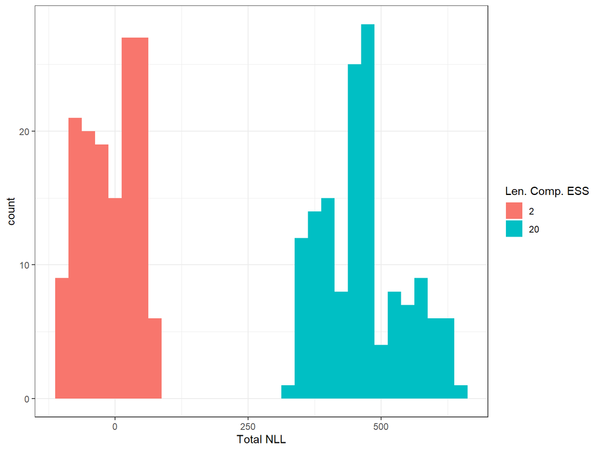

Figure 3. Histogram of the total negative log-likelihood (NLL) with filled colours indicating the two values for the effective sample size for the length composition (Len. Comp. ESS).

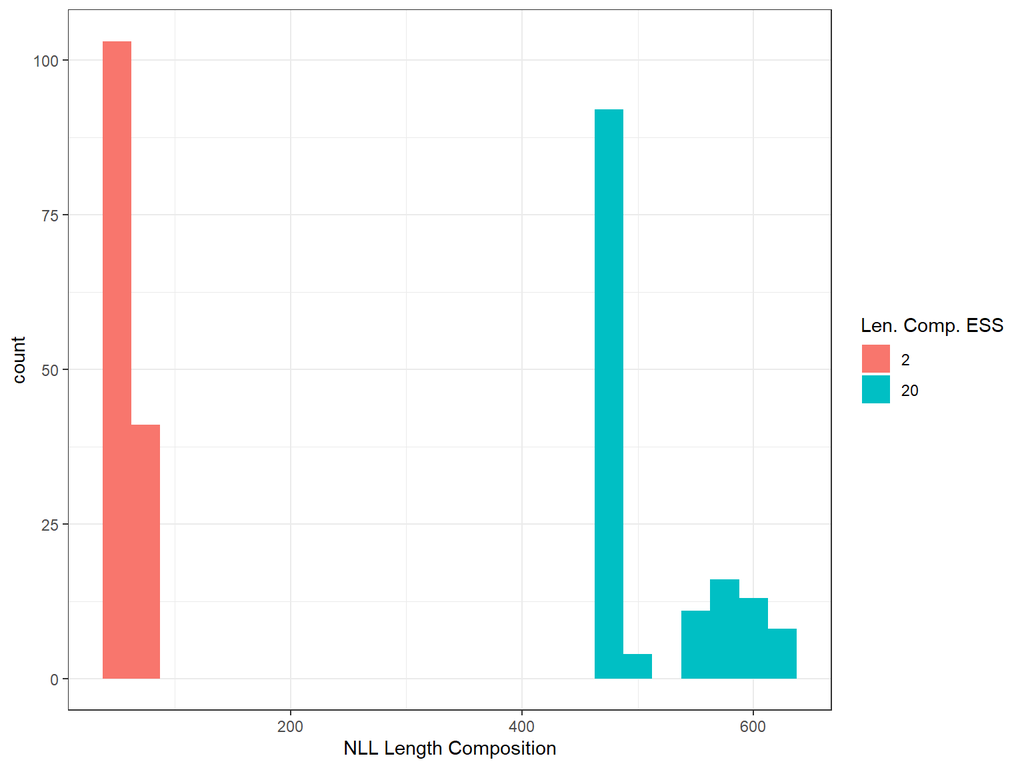

Figure 4. Histogram of the NLL for the length composition data with filled colours indicating the two values for the effective sample size for the length composition (Len. Comp. ESS).

## 6.1 Comparing Model Fits to Length Composition Data

To compare the fits to the length composition data the NLL of the length composition with effective sample size 2 was up-weighted by a factor of 10 (Figure 5). Figure 6 shows a histogram of the estimated 2017 stock status with colours indicating 4 discrete levels of the up-weighted NLL for the length composition.

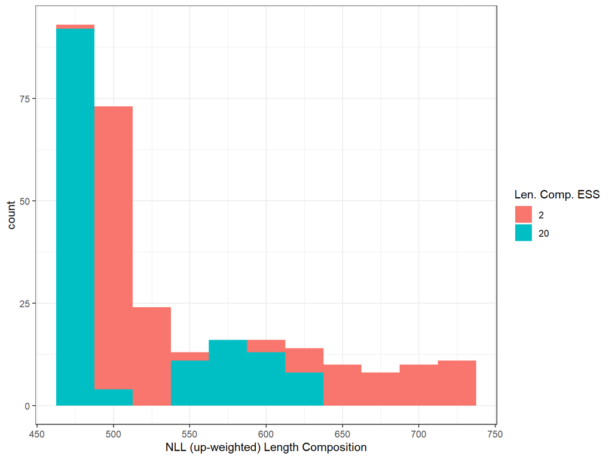

Figure 5. Histogram of the NLL for the length composition data, where NLL for effective sample size 2 was up-weighted by a factor of 10, with filled colours indicating the two values for the effective sample size for the length composition (Len. Comp. ESS).

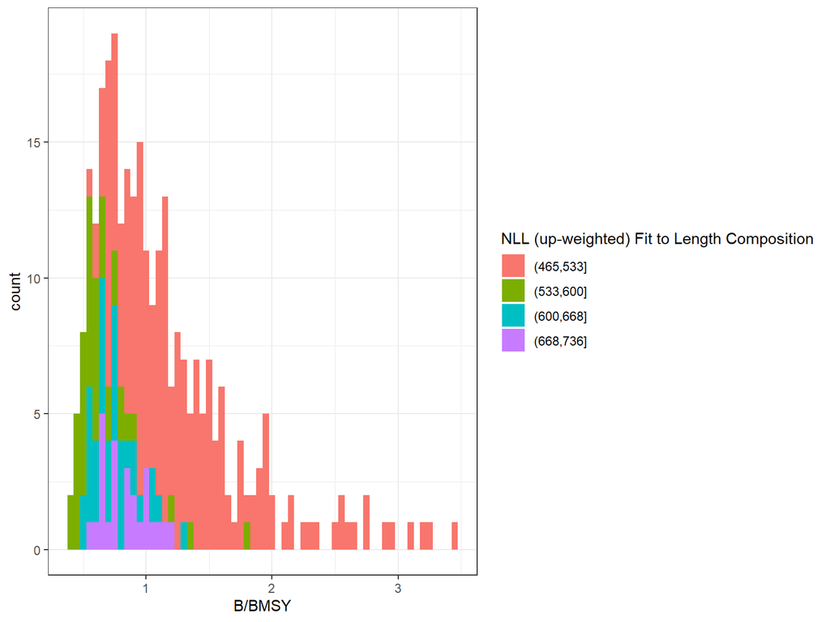

Figure 6. Histogram of estimated stock status (B/BMSY) in 2017 for the length composition data, where NLL for effective sample size 2 was up-weighted by a factor of 10, and NLL values grouped into 4 discrete classes.

# 7 SB/SB<sub>MSY</sub> Timeseries Plots

Time-series plots of the spawning biomass (SB) relative to spawning biomass corresponding with maximum sustainable yield (SB<sub>MSY</sub>) for the seven factors examined in the uncertainty grid.

## 7.1 Natural Mortality

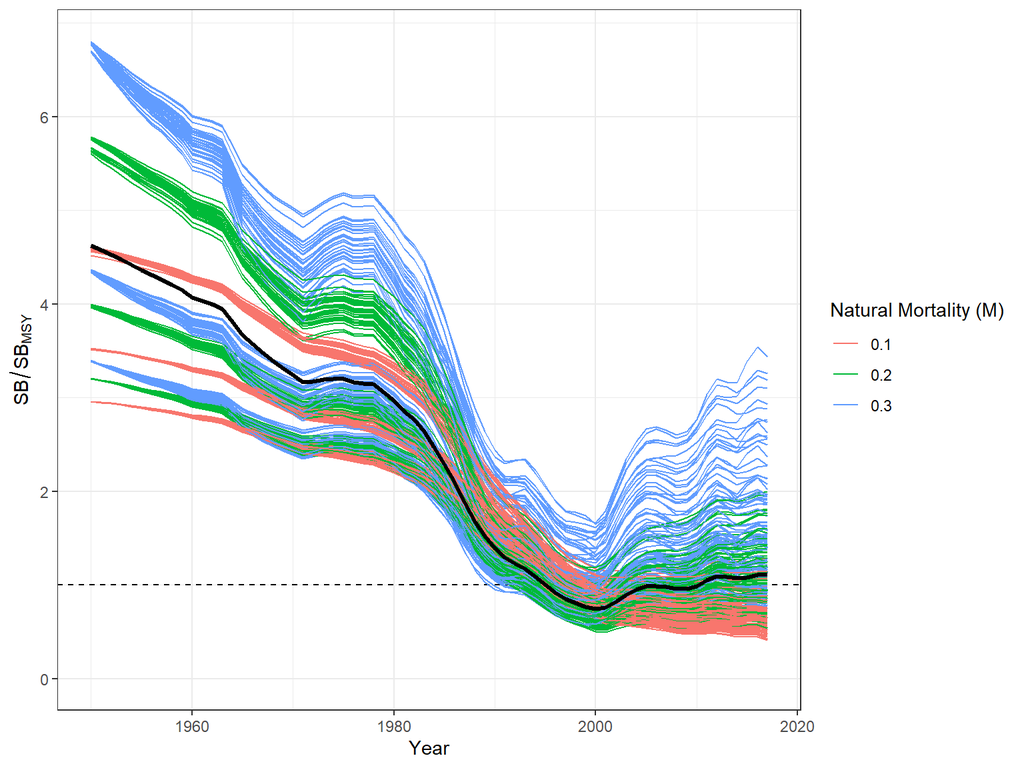

Figure 7. Predicted spawning biomass (SB) relative to spawning biomass at maximum sustainable yield (SB<sub>MSY</sub>) for the 288 OMs from the uncertainty grid with the 3 levels of Natural Mortality (M) shown as coloured lines. The base case OM is shown as the thick black line.

## 7.2 Recruitment Variability

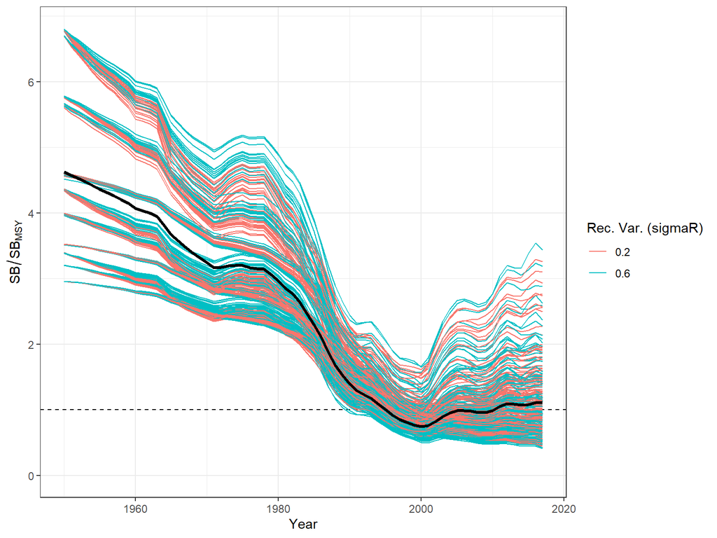

Figure 8. Predicted spawning biomass (SB) relative to spawning biomass at maximum sustainable yield (SB<sub>MSY</sub>) for the 288 OMs from the uncertainty grid with the 2 levels of Rec. Var. (sigmaR) shown as coloured lines. The base case OM is shown as the thick black line.

## 7.3 Steepness

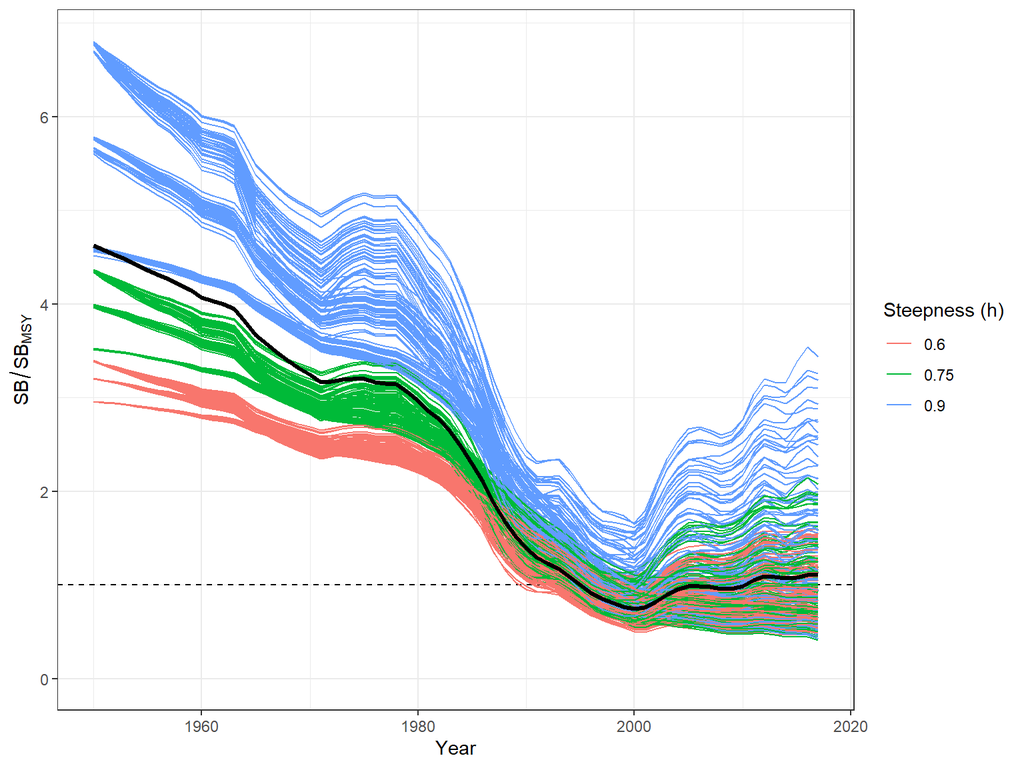

Figure 9. Predicted spawning biomass (SB) relative to spawning biomass at maximum sustainable yield (SB<sub>MSY</sub>) for the 288 OMs from the uncertainty grid with the 3 levels of Steepness (h) shown as coloured lines.

## 7.4 CPUE CV

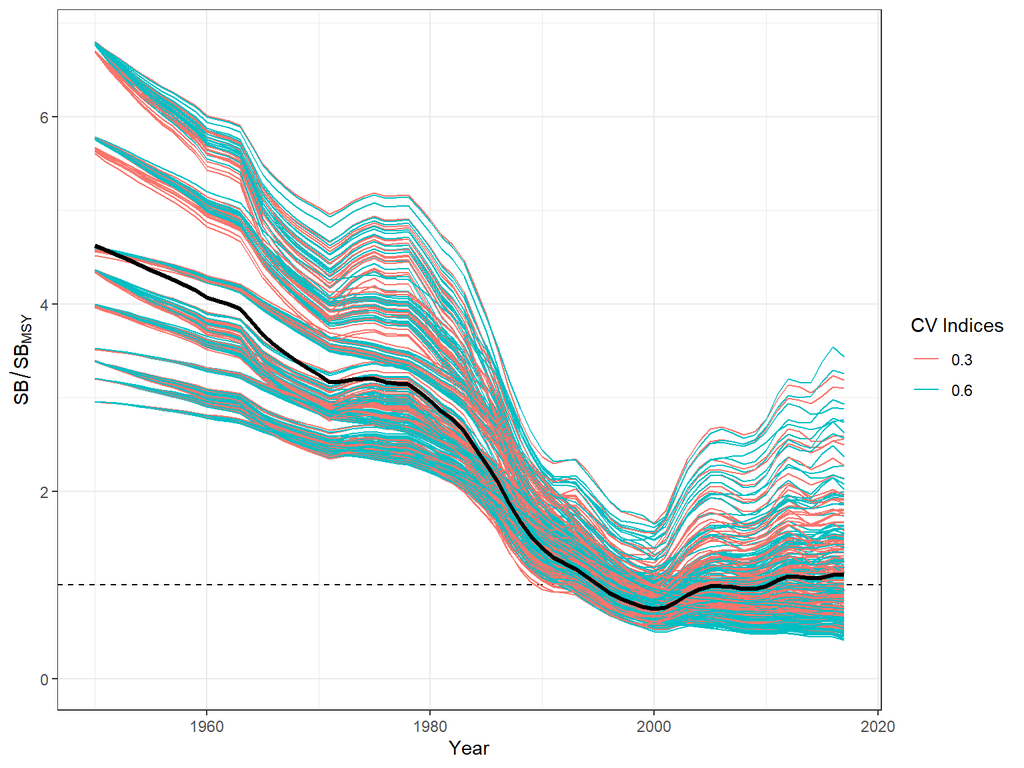

Figure 10. Predicted spawning biomass (SB) relative to spawning biomass at maximum sustainable yield (SB<sub>MSY</sub>) for the 288 OMs from the uncertainty grid with the 2 levels of CV Indices shown as coloured lines. The base case OM is shown as the thick black line.

## 7.5 Length Comp. ESS

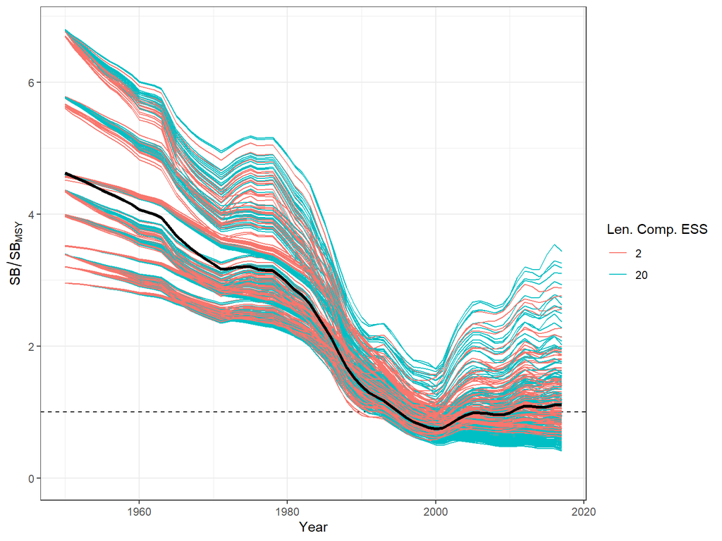

Figure 11. Predicted spawning biomass (SB) relative to spawning biomass at maximum sustainable yield (SB<sub>MSY</sub>) for the 288 OMs from the uncertainty grid with the 2 levels of Len. Comp. ESS shown as coloured lines. The base case OM is shown as the thick black line.

## 7.6 Catchability Increase

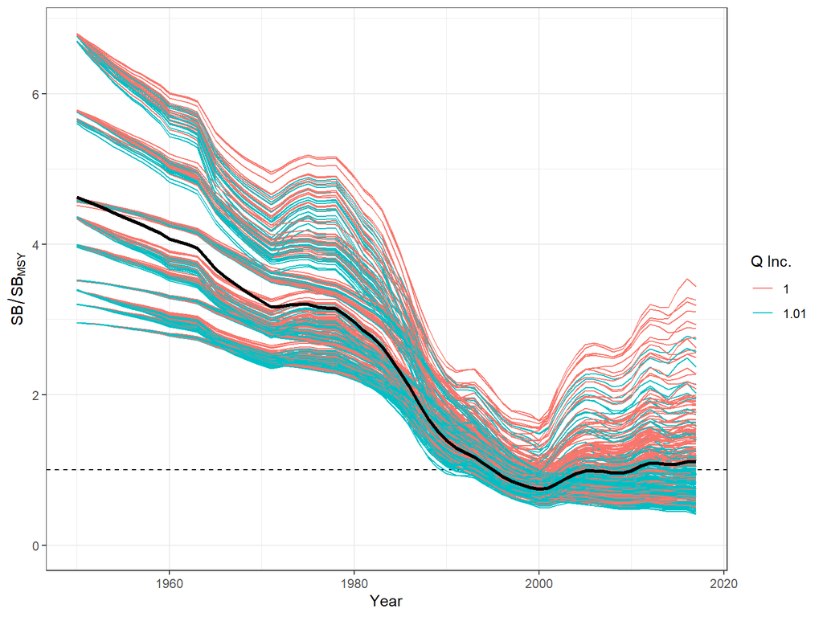

Figure 12. Predicted spawning biomass (SB) relative to spawning biomass at maximum sustainable yield (SB<sub>MSY</sub>) for the 288 OMs from the uncertainty grid with the 2 levels of Q Inc. shown as coloured lines. The base case OM is shown as the thick black line.

## 7.7 Environmental Covariate

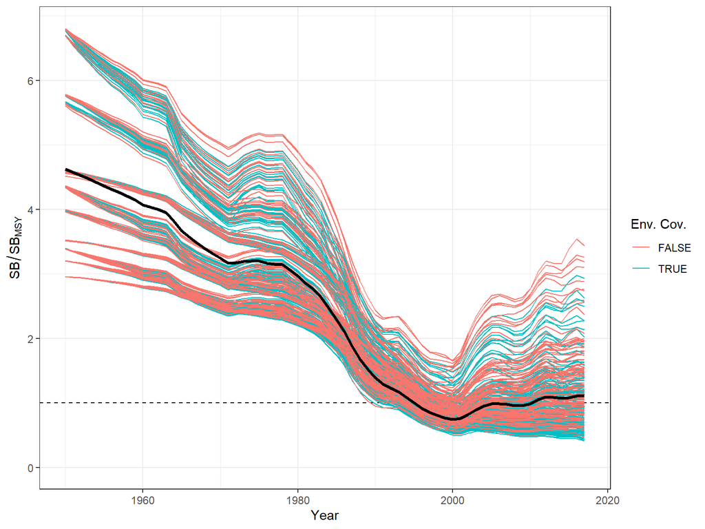

Figure 13. Predicted spawning biomass (SB) relative to spawning biomass at maximum sustainable yield (SB<sub>MSY</sub>) for the 288 OMs from the uncertainty grid with the 2 levels of Env. Cov. shown as coloured lines.

# 8 Current SB/SB<sub>MSY</sub> Histograms

## 8.1 Natural Mortality

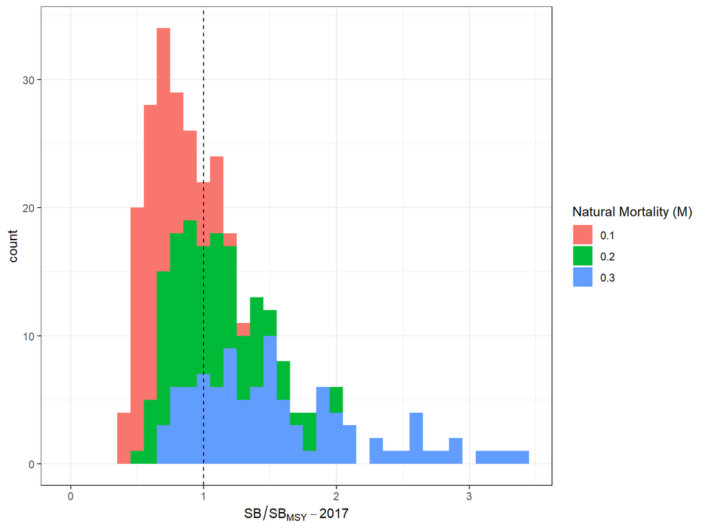

Figure 14. Histogram of predicted spawning biomass (SB) relative to spawning biomass at maximum sustainable yield (SB<sub>MSY</sub>) for the 288 OMs from the uncertainty grid with the 3 levels of Natural Mortality (M).

## 8.2 Recruitment Variability

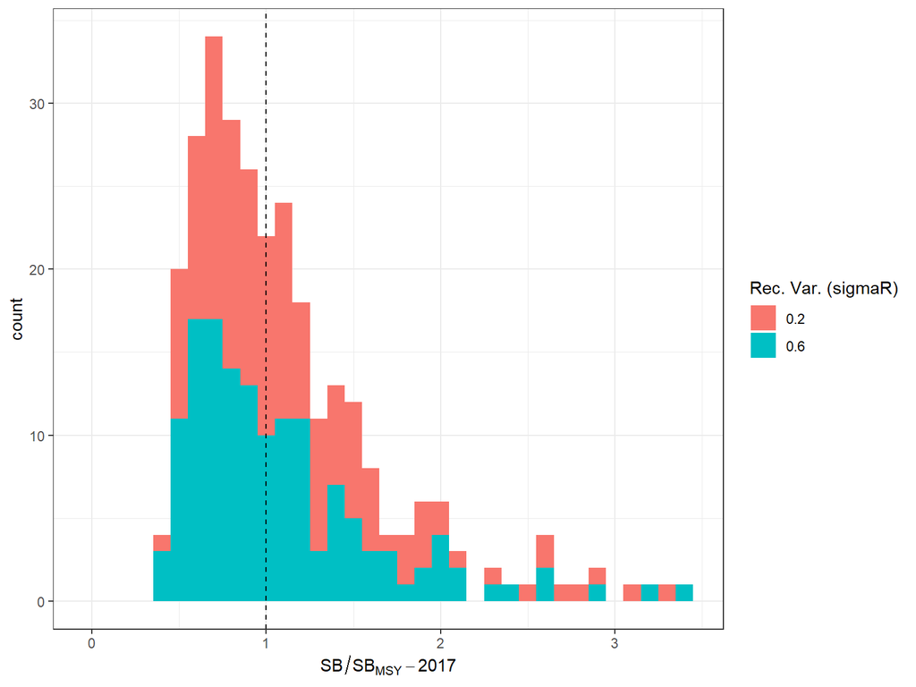

Figure 15. Histogram of predicted spawning biomass (SB) relative to spawning biomass at maximum sustainable yield (SB<sub>MSY</sub>) for the 288 OMs from the uncertainty grid with the 2 levels of Rec. Var. (sigmaR).

## 8.3 Steepness

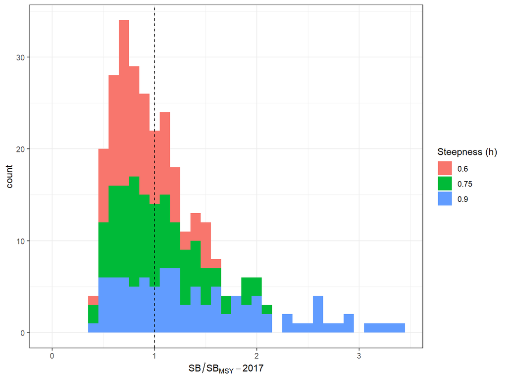

Figure 16. Histogram of predicted spawning biomass (SB) relative to spawning biomass at maximum sustainable yield (SB<sub>MSY</sub>) for the 288 OMs from the uncertainty grid with the 3 levels of Steepness (h).

## 8.4 CPUE CV

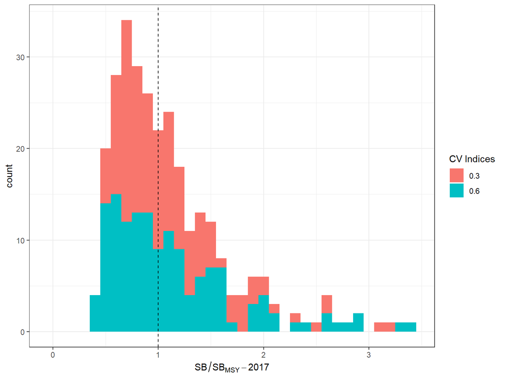

Figure 17. Histogram of predicted spawning biomass (SB) relative to spawning biomass at maximum sustainable yield (SB<sub>MSY</sub>) for the 288 OMs from the uncertainty grid with the 2 levels of CV Indices.

## 8.5 Length Comp. ESS

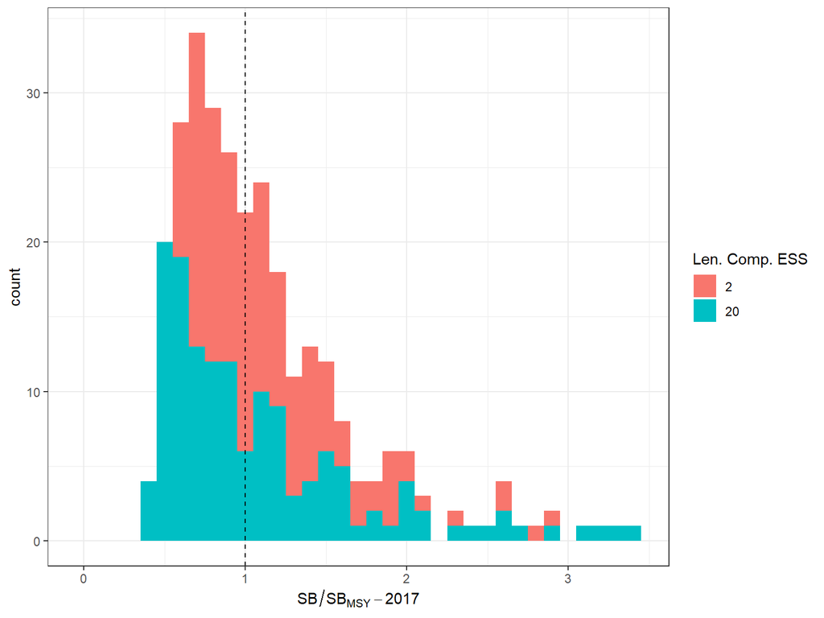

Figure 18. Histogram of predicted spawning biomass (SB) relative to spawning biomass at maximum sustainable yield (SB<sub>MSY</sub>) for the 288 OMs from the uncertainty grid with the 2 levels of Len. Comp. ESS.

## 8.6 Catchability Increase

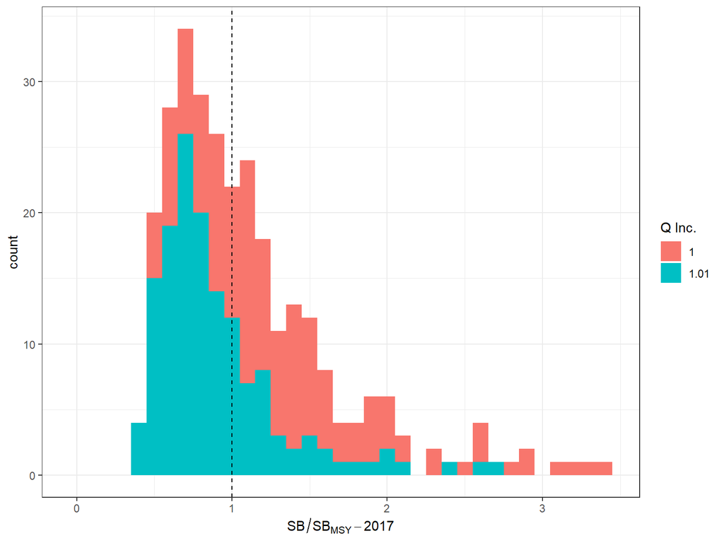

Figure 19. Histogram of predicted spawning biomass (SB) relative to spawning biomass at maximum sustainable yield (SB<sub>MSY</sub>) for the 288 OMs from the uncertainty grid with the 2 levels of Q Inc..

## 8.7 Environmental Covariate

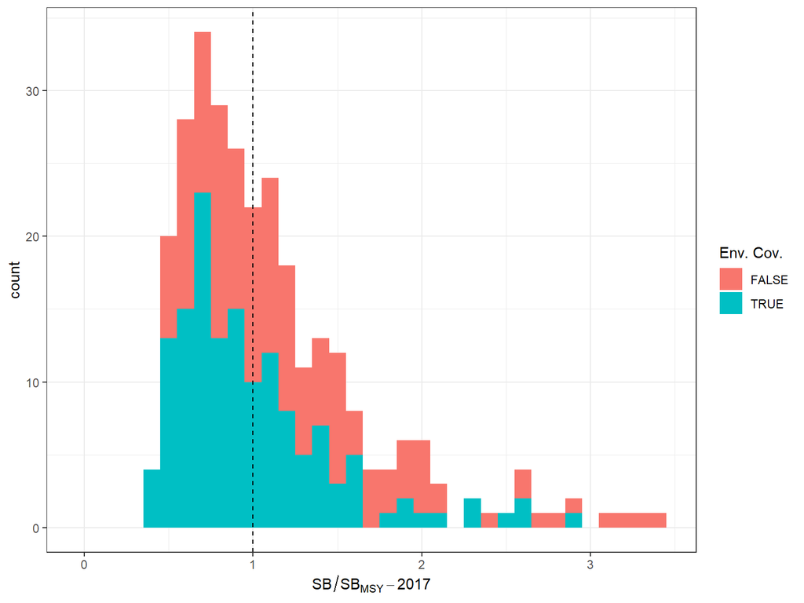

Figure 20. Histogram of predicted spawning biomass (SB) relative to spawning biomass at maximum sustainable yield (SB<sub>MSY</sub>) for the 288 OMs from the uncertainty grid with the 2 levels of Env. Cov..

# 9 Current SB/SB<sub>MSY</sub> Bi-Variate Boxplots

Bivariate boxplots of the spawning biomass (SB) relative to spawning biomass corresponding with maximum sustainable yield (SB<sub>MSY</sub>) for the factors examined in the uncertainty grid.

## 9.1 Natural Mortality

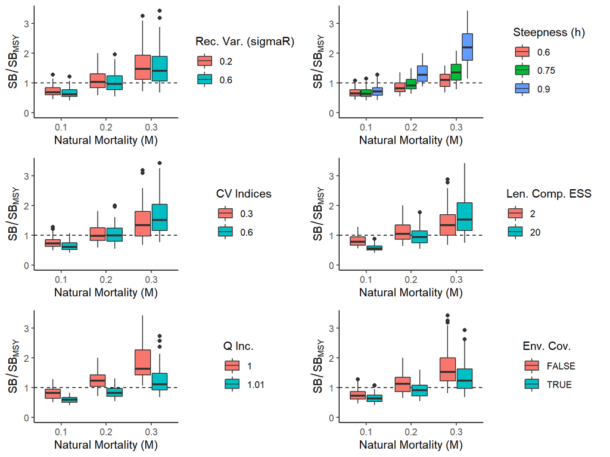

Figure 21. Boxplots of predicted spawning biomass (SB) relative to spawning biomass at maximum sustainable yield (SB<sub>MSY</sub>) for the 288 OMs from the uncertainty grid with the 3 levels of Natural Mortality shown as factors on the x-axis and colours indicating the other factors.

## 9.2 Recruitment Variability

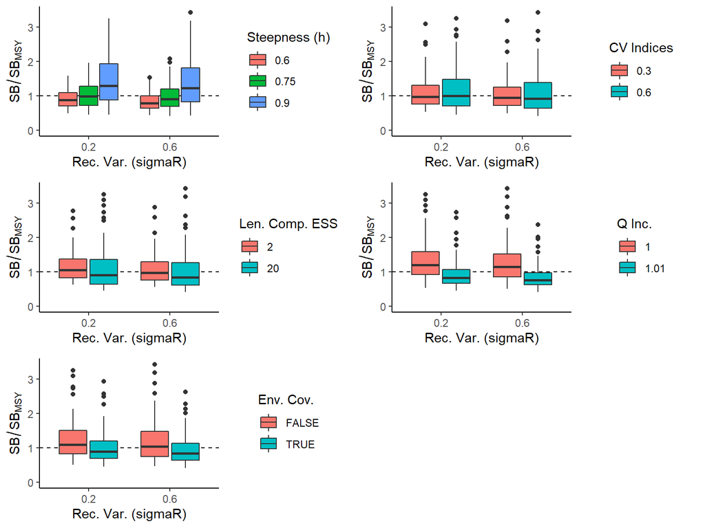

Figure 22. Boxplots of predicted spawning biomass (SB) relative to spawning biomass at maximum sustainable yield (SB<sub>MSY</sub>) for the 288 OMs from the uncertainty grid with the 2 levels of Recruitment Variability shown as factors on the x-axis and colours indicating the other factors.

## 9.3 Steepness

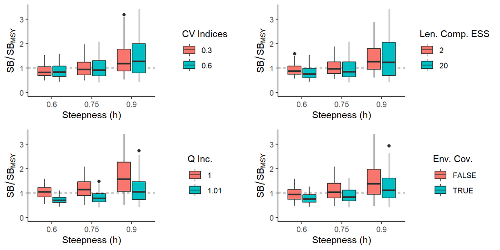

Figure 23. Boxplots of predicted spawning biomass (SB) relative to spawning biomass at maximum sustainable yield (SB<sub>MSY</sub>) for the 288 OMs from the uncertainty grid with the 3 levels of Steepness shown as factors on the x-axis and colours indicating the other factors.

## 9.4 CPUE CV

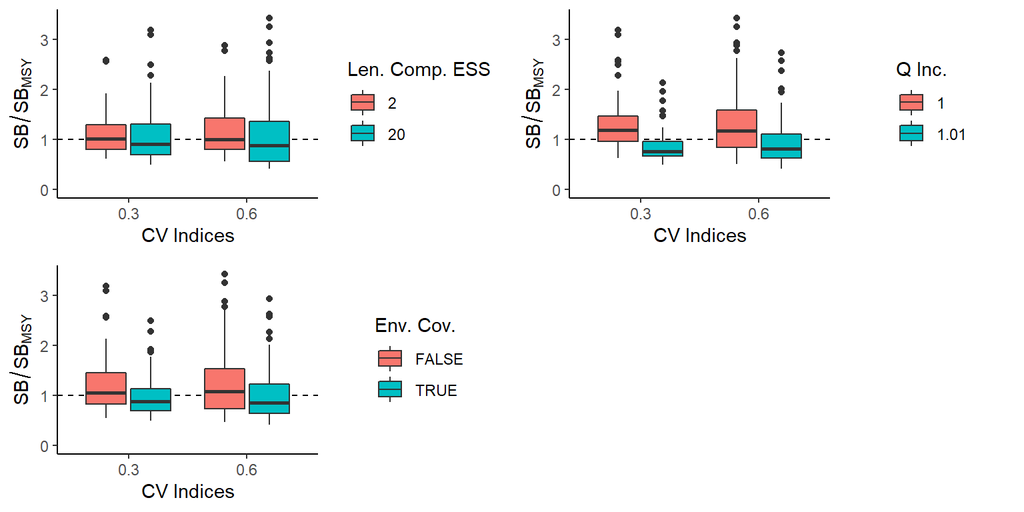

Figure 24. Boxplots of predicted spawning biomass (SB) relative to spawning biomass at maximum sustainable yield (SB<sub>MSY</sub>) for the 288 OMs from the uncertainty grid with the 2 levels of CV Indices shown as factors on the x-axis and colours indicating the other factors.

## 9.5 Length Comp. ESS

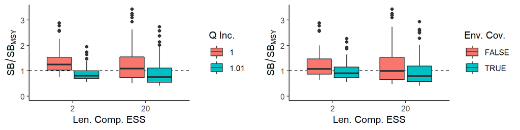

Figure 25. Boxplots of predicted spawning biomass (SB) relative to spawning biomass at maximum sustainable yield (SB<sub>MSY</sub>) for the 288 OMs from the uncertainty grid with the 2 levels of Length Composition Effective Sample Size shown as factors on the x-axis and colours indicating the other factors.

## 9.6 Catchability Increase

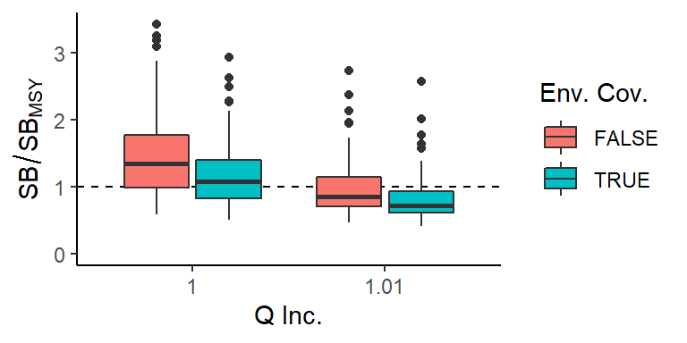

Figure 26. Boxplots of predicted spawning biomass (SB) relative to spawning biomass at maximum sustainable yield (SB<sub>MSY</sub>) for the 288 OMs from the uncertainty grid with the 2 levels of Q Increase shown as factors on the x-axis and colours indicating the other factors.

# 10 Impact of M and h on Estimated Parameters

## 10.1 Unfished Recruitment (R0)

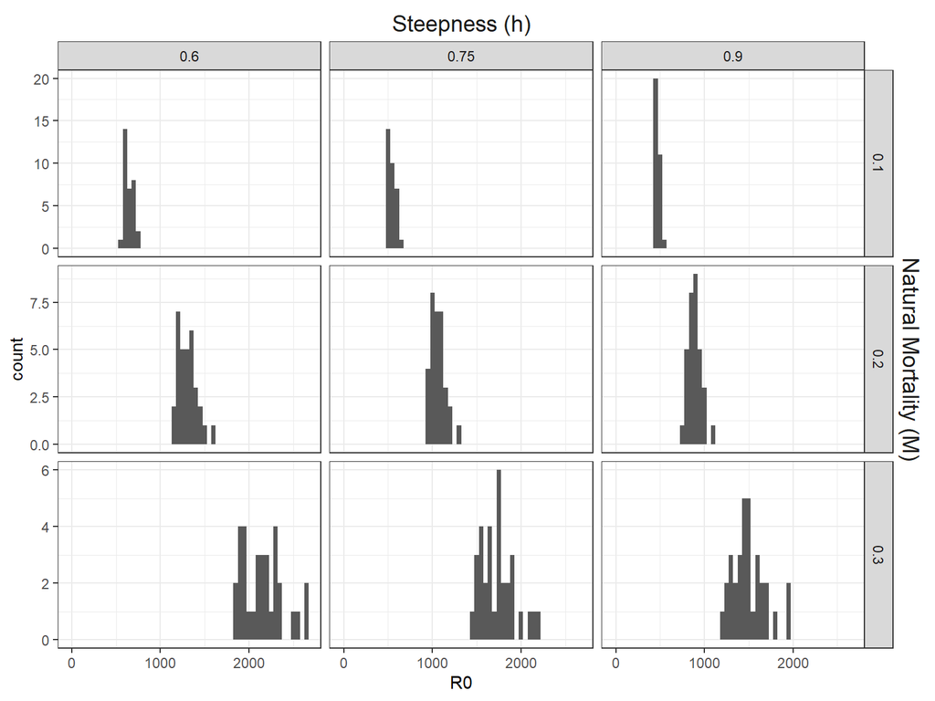

Figure 27. Histograms of estimated unfished recruitment (R0) faceted by 3 levels of natural mortality (M) and 3 levels of steepness (h).

## 10.2 Depletion

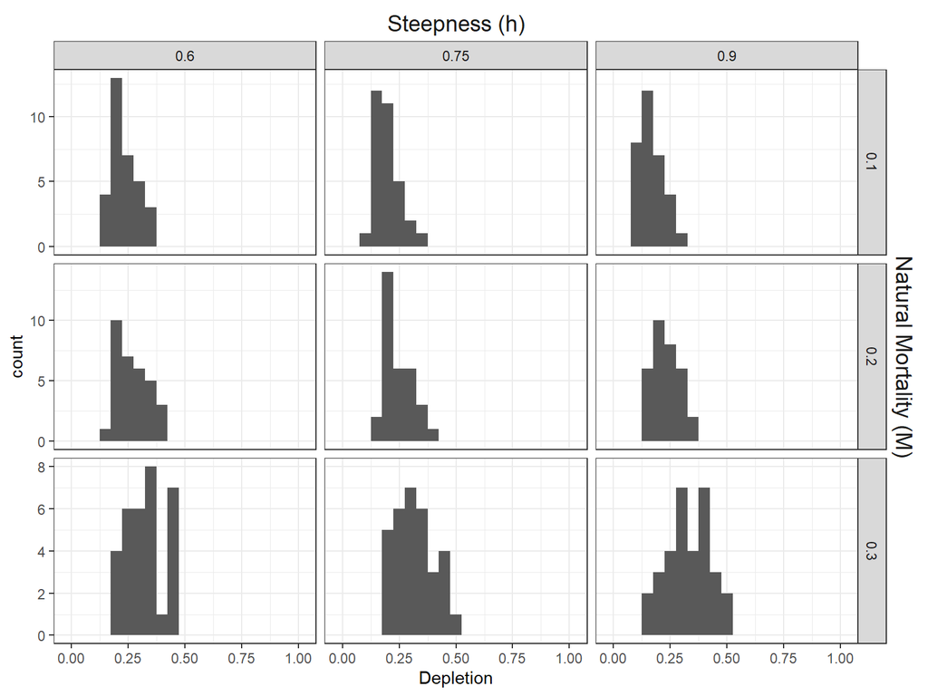

Figure 28. Histograms of estimated depletion (SB/SB0) faceted by 3 levels of natural mortality (M) and 3 levels of steepness (h).

## 10.3 SB<sub>MSY</sub>

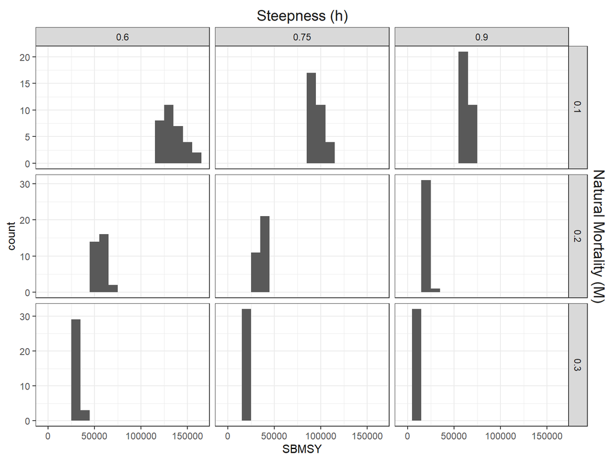

Figure 29. Histograms of estimated SB<sub>MSY</sub> faceted by 3 levels of natural mortality (M) and 3 levels of steepness (h).

## 10.4 SSB

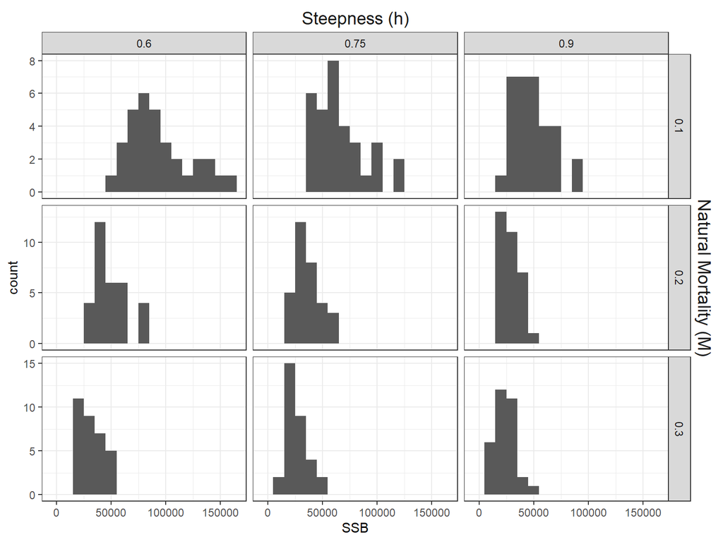

Figure 30. Histograms of estimated SSB faceted by 3 levels of natural mortality (M) and 3 levels of steepness (h).

## 10.5 SB0

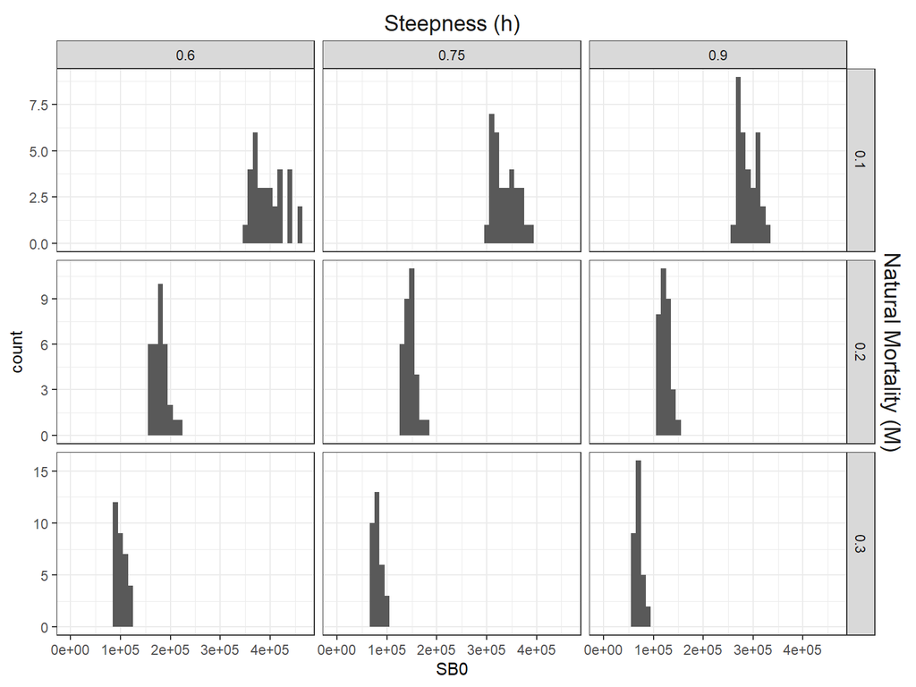

Figure 31. Histograms of estimated SB0 faceted by 3 levels of natural mortality (M) and 3 levels of steepness (h).